# Final_Project

## FUNDAMENTALS OF DATA VISUALIZATION

**Name**: *Willian Pina Botelho*

### 1. Recap of Data, Goals, and Tasks:

The dataset used was extracted from Kaggle and contains information about data scientist job vacancies in the UK. The data includes attributes such as company name, company rating, job title, location, publication date, estimated salary range, required skills, and whether the job is remote or on-site.

#### Main Goals:

- **Analyze salary variation**: Explore how data scientist salaries vary across cities and regions in the UK.
- **Identify the most in-demand skills**: Discover which skills are most sought after and how they influence salaries.
- **Evaluate the relationship between company rating and remote jobs**: Investigate whether companies with higher ratings offer more remote job opportunities or higher salaries.

#### Key Tasks:

- Salary variation analysis using bar charts and boxplots to compare salary distributions.
- Identification of the most in-demand skills using horizontal bar charts and word clouds.
- Evaluation of the correlation between company ratings and salaries using scatter plots and histograms.

### 2. Screenshots and Link to Visualization Implementation:

Here are some screenshots of the developed interactive visualizations:

- **Boxplot showing salary variation by region** (Example of cities with the highest and lowest salaries).
- **Word cloud of the most in-demand skills** (Examples include skills like Python, SQL, and Machine Learning).
- **Scatter plot showing the correlation between company rating and salary range**.

```python
import altair as alt
import pandas as pd
from collections import Counter
from wordcloud import WordCloud
import matplotlib.pyplot as plt
import seaborn as sns

# Load the data from the CSV file
data = pd.read_csv('data/Cleaned_Dataset.csv')
# Filter rows with valid salary data
data = data.dropna(subset=['Salary', 'City', 'Country'])

# Boxplot for salary variation by city
city_chart = alt.Chart(data).mark_boxplot().encode(
    x=alt.X('City:N', sort='-y', title='City'),
    y=alt.Y('Salary:Q', title='Salary'),
    tooltip=['City', 'Salary']
).properties(
    title='Salary Distribution Across Cities in the UK',
    width=900,
    height=300
)

# Boxplot for salary variation by country
country_chart = alt.Chart(data).mark_boxplot().encode(
    x=alt.X('Country:N', sort='-y', title='Country'),
    y=alt.Y('Salary:Q', title='Salary'),
    tooltip=['Country', 'Salary']
).properties(
    title='Salary Distribution Across Countries',
    width=600,
    height=300
)

# Display the charts side by side
final_chart = city_chart | country_chart
final_chart.display()
```

[interactive chart not shown]

Based on the presented boxplots, which show the salary distribution across cities in the UK and countries, we can draw the following conclusions:

1. **Salary Distribution Across Cities in the UK (Left)**
   - **London**: London is clearly a city with a wide salary range and shows some of the highest salaries, including several outliers, which indicate high-paying positions in the data science market. London is one of the most important and expensive cities in the UK, which can explain this larger variation.
   - **Cities with Significant Variation**: Besides London, other cities like **Leeds** and **Reading** also show a wide salary range, though not as high as London.
   - **Cities with Lower Salaries and Less Variation**: Cities like **Sheffield**, **Bristol**, and **Southampton** seem to have a narrower and generally lower salary range, suggesting that job opportunities in these areas are more homogeneous in terms of compensation.
2. **Salary Distribution Across Countries in the UK (Right)**
   - **England**: The salary range in England is the widest compared to Scotland, Wales, and Northern Ireland. This may reflect the greater economic diversity and larger number of tech and data science companies based in England.
   - **Scotland and Northern Ireland**: Both countries have a more restricted salary range, with lower average salaries, suggesting less variation in the salaries offered for data science positions.
   - **Wales**: Shows a moderately wide salary range, with the median salary higher than in Scotland and Northern Ireland, indicating that there may be some good opportunities in the data science job market in Wales.
3. Overall Conclusion:
   - **London** remains the main hub for high-paying opportunities, with a wide range of salaries, indicating that the city has strong and diverse demand for data scientists.
   - **Cities like Leeds and Reading** also show good salary opportunities, but with fewer outliers compared to London, suggesting that these cities have less salary variation.
   - **Scotland and Northern Ireland** offer, on average, lower and more homogeneous salaries, while **Wales** shows competitive salaries with a relatively high median.

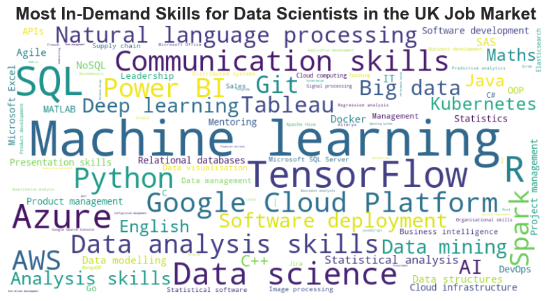

```python
# Extracting the skills column and splitting the skills into individual items
skills_list = data['Skills'].dropna().str.split(', ')

# Flatten the list of lists into a single list
all_skills = [skill for sublist in skills_list for skill in sublist]

# Count the frequency of each skill
skill_counts = Counter(all_skills)

# Create a word cloud visualization
wordcloud = WordCloud(width=800, height=400, background_color='white').generate_from_frequencies(skill_counts)

# Display the word cloud
plt.figure(figsize=(10, 5))
plt.imshow(wordcloud, interpolation='bilinear')
plt.axis('off')
plt.title('Most In-Demand Skills for Data Scientists in the UK Job Market', fontsize=18, fontweight='bold')
plt.show()
```

Based on the presented "Word Cloud," which shows the most in-demand skills for data scientists in the UK job market, we can draw the following conclusions: